# Ford GoBike System Data Exploration

### Bivariate Exploration

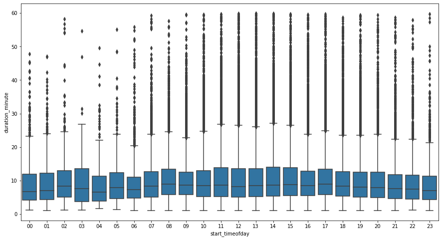

```python
plt.figure(figsize = [15,8 ])
sb.boxplot(data = df, x = 'start_timeofday', y = 'duration_minute', color = base_color);
```

- The median duration doesn't differ so much between hours.

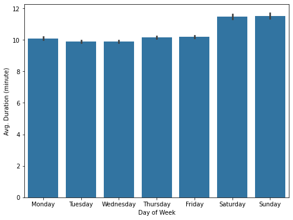

```python
plt.figure(figsize = [8, 6])
base_color = sb.color_palette()[0]
sb.barplot(data = df, x = 'start_dayofweek', y = 'duration_minute', color = base_color)
plt.ylabel('Avg. Duration (minute)')
plt.xlabel('Day of Week');
```

- The trips duration on Saturday and Sunday is longer than the other days. People on weekends use bikes for fun and entertainment.

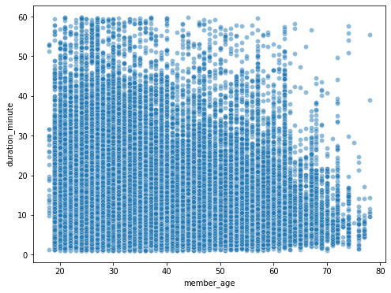

```python
plt.figure(figsize = [8, 6])
sb.scatterplot(data = df, x = 'member_age', y = 'duration_minute', alpha = 0.5);
```

- The relationship between members' age and trips duration is negative.

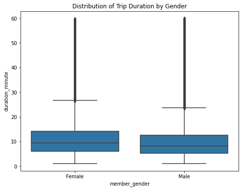

```python
plt.figure(figsize = [8, 6])
sb.boxplot(data = df, x = 'member_gender', y = 'duration_minute', color = base_color)
plt.title('Distribution of Trip Duration by Gender');
```

- Females go on trips longer than males but by a small difference.

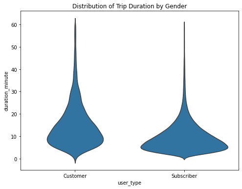

```python
plt.figure(figsize = [8, 6])
sb.violinplot(data = df, x = 'user_type', y = 'duration_minute', inner = None, color = base_color)
plt.title('Distribution of Trip Duration by Gender');
```

- Subscribers go on trips less on time than customers go. Most subscribers go on less than 10-minute trips.

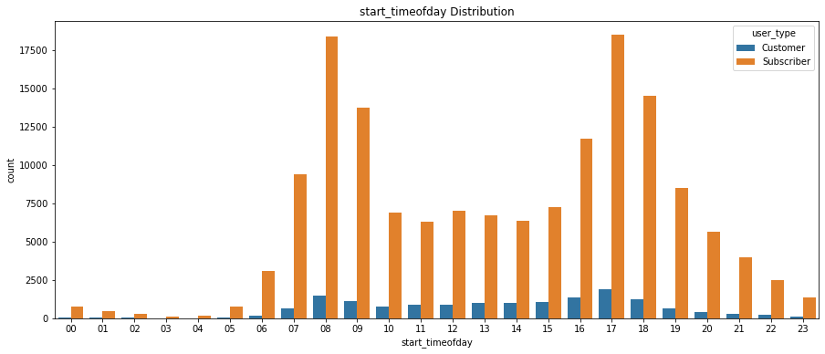

```python
plt.figure(figsize = [15, 6])
countplot_proportions(data = df, x = 'start_timeofday', hue = 'user_type')
```

- Most of People who ride bikes at 8 am - 9 am or 5 pm-6 pm are subscribers. These times when people go to work or study.

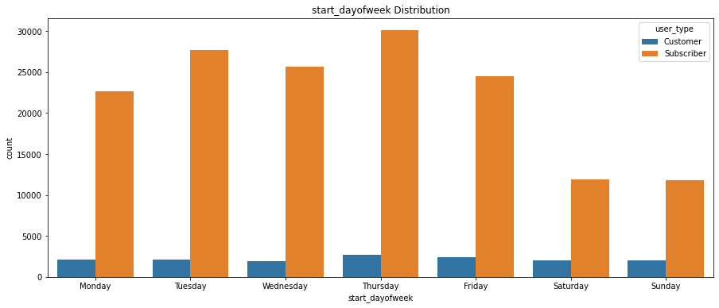

```python
plt.figure(figsize = [15, 6])
countplot_proportions(data = df, x = 'start_dayofweek', hue = 'user_type')
```

- From this graph, we can be sure that people who go to work or study are subscribers. On the weekdays, the number of subscribers is greater than on the weekends.